# Correlations

# Correlation between other parameters:

all focus conditions are considered

Subsets per group/ treatment condition

```r
data_CON <- filter(data_new, med_con %in% c('Control'))
data_medOFF <- filter(data_new, med_con %in% c('med-OFF'))
data_medON <- filter(data_new, med_con %in% c('med-ON'))
data_DBSON <- filter(data_new, med_con %in% c('med-OFF/DBS-ON'))
```

# Which factors are responsible for longer acoustic durations

Acoustic vowel duration ~ TB DUR

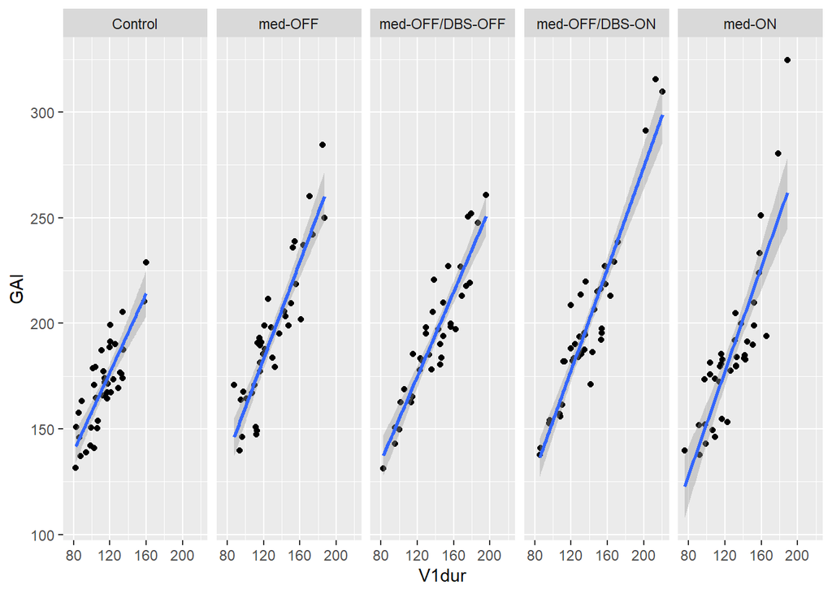

```r
ggplot(data_new, aes(x=V1dur, y=GAI)) +
  geom_point()+
  geom_smooth(method=lm)+
  facet_grid(.~med_con)
```

Calculate correlation coefficient between V1.dur and TB DUR

```r
## med-OFF
shapiro.test(data_medOFF$GAI) # p = 0.1508
```

```
##
##  Shapiro-Wilk normality test
##
## data:  data_medOFF$GAI
## W = 0.95782, p-value = 0.1508
```

```r
shapiro.test(data_medOFF$V1dur) # p =  0.07116
```

```
##
##  Shapiro-Wilk normality test
##
## data:  data_medOFF$V1dur
## W = 0.94814, p-value = 0.07116
```

```r
cor.test(data_medOFF$GAI, data_medOFF$V1dur, method = "pearson") ## r(37) = 0.90, p < .001
```

```
##
##  Pearson's product-moment correlation
##
## data:  data_medOFF$GAI and data_medOFF$V1dur
## t = 12.614, df = 37, p-value = 5.727e-15
## alternative hypothesis: true correlation is not equal to 0
## 95 percent confidence interval:
##  0.8175833 0.9470958
## sample estimates:
##       cor
## 0.9007433
```

```r
## med-ON
shapiro.test(data_medON$GAI) # p = 5.182e-05
```

```
##
##  Shapiro-Wilk normality test
##
## data:  data_medON$GAI
## W = 0.83636, p-value = 5.182e-05
```

```r
shapiro.test(data_medON$V1dur) # p = 0.8247
```

```
##
##  Shapiro-Wilk normality test
##
## data:  data_medON$V1dur
## W = 0.98346, p-value = 0.8247
```

```r
cor.test(data_medON$GAI, data_medON$V1dur, method = "spearman") ## r(37) = 0.87, p < .001
```

```
##
##  Spearman's rank correlation rho
##
## data:  data_medON$GAI and data_medON$V1dur
## S = 1246, p-value < 2.2e-16
## alternative hypothesis: true rho is not equal to 0
## sample estimates:
##       rho
## 0.8738866
```

```r
## DBS-ON
shapiro.test(data_DBSON$GAI) # p = 0.0004434
```

```
##
##  Shapiro-Wilk normality test
##
## data:  data_DBSON$GAI
## W = 0.87451, p-value = 0.0004434
```

```r
shapiro.test(data_DBSON$V1dur) # p = 0.05746
```

```
##
##  Shapiro-Wilk normality test
##
## data:  data_DBSON$V1dur
## W = 0.94538, p-value = 0.05746
```

```r
cor.test(data_DBSON$GAI, data_DBSON$V1dur, method = "spearman") ## r(37) = 0.87, p < .001
```

```
##
##  Spearman's rank correlation rho
##
## data:  data_DBSON$GAI and data_DBSON$V1dur
## S = 1242, p-value < 2.2e-16
## alternative hypothesis: true rho is not equal to 0
## sample estimates:
##       rho
## 0.8742915
```

# Which factors are responsible for smaller VAI values?

VAI ~ UPDRS

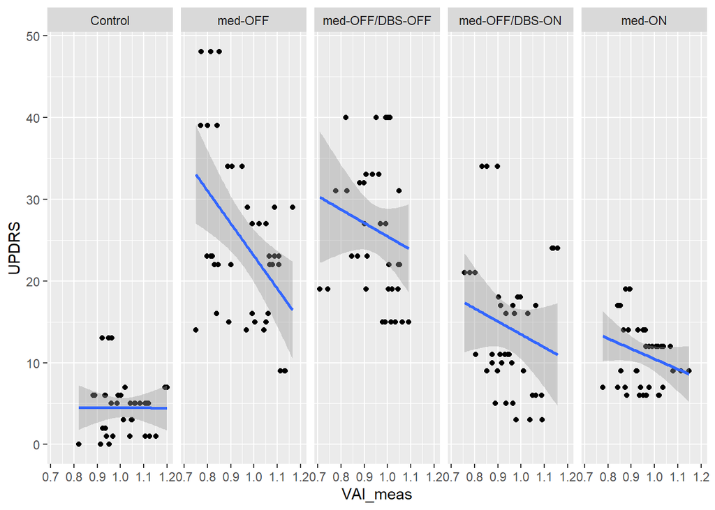

```r
ggplot(data_new, aes(x=VAI_meas, y=UPDRS)) +
  geom_point()+
  geom_smooth(method=lm)+
  facet_grid(.~med_con)
```

Calculate correlation coefficient between VAI and UPDRS

```r
## med-OFF
shapiro.test(data_medOFF$VAI_meas) # p = 0.0165
```

```
##
##  Shapiro-Wilk normality test
##
## data:  data_medOFF$VAI_meas
## W = 0.92884, p-value = 0.0165
```

```r
shapiro.test(data_medOFF$UPDRS) # p = 0.0153
```

```
##
##  Shapiro-Wilk normality test
##
## data:  data_medOFF$UPDRS
## W = 0.92781, p-value = 0.0153
```

```r
cor.test(data_medOFF$VAI_meas, data_medOFF$UPDRS, method = "spearman") ## r(37) = -0.38, p = 0.01662
```

```
##
##  Spearman's rank correlation rho
##
## data:  data_medOFF$VAI_meas and data_medOFF$UPDRS
## S = 13647, p-value = 0.01662
## alternative hypothesis: true rho is not equal to 0
## sample estimates:
##       rho
## -0.381302
```

```r
## med-ON
shapiro.test(data_medON$VAI_meas) # p = 0.8574
```

```
##
##  Shapiro-Wilk normality test
##
## data:  data_medON$VAI_meas
## W = 0.98449, p-value = 0.8574
```

```r
shapiro.test(data_medON$UPDRS) # p = 0.004
```

```
##
##  Shapiro-Wilk normality test
##
## data:  data_medON$UPDRS
## W = 0.90886, p-value = 0.004
```

```r
cor.test(data_medON$VAI_meas, data_medON$UPDRS, method = "spearman") ## r(37) = -0.25, n.s.
```

```
##
##  Spearman's rank correlation rho
##
## data:  data_medON$VAI_meas and data_medON$UPDRS
## S = 12322, p-value = 0.1292
## alternative hypothesis: true rho is not equal to 0
## sample estimates:
##        rho
## -0.2472017
```

```r
## DBS-ON
shapiro.test(data_DBSON$VAI_meas) # p = 0.8184
```

```
##
##  Shapiro-Wilk normality test
##
## data:  data_DBSON$VAI_meas
## W = 0.98327, p-value = 0.8184
```

```r
shapiro.test(data_DBSON$UPDRS) # p = 0.006692
```

```
##
##  Shapiro-Wilk normality test
##
## data:  data_DBSON$UPDRS
## W = 0.91629, p-value = 0.006692
```

```r
cor.test(data_DBSON$VAI_meas, data_DBSON$UPDRS, method = "spearman") ## r(37) = -0.22, n.s.
```

```
##
##  Spearman's rank correlation rho
##
## data:  data_DBSON$VAI_meas and data_DBSON$UPDRS
## S = 12061, p-value = 0.1769
## alternative hypothesis: true rho is not equal to 0
## sample estimates:
##        rho
## -0.2207223
```

VAI ~ axial symptoms

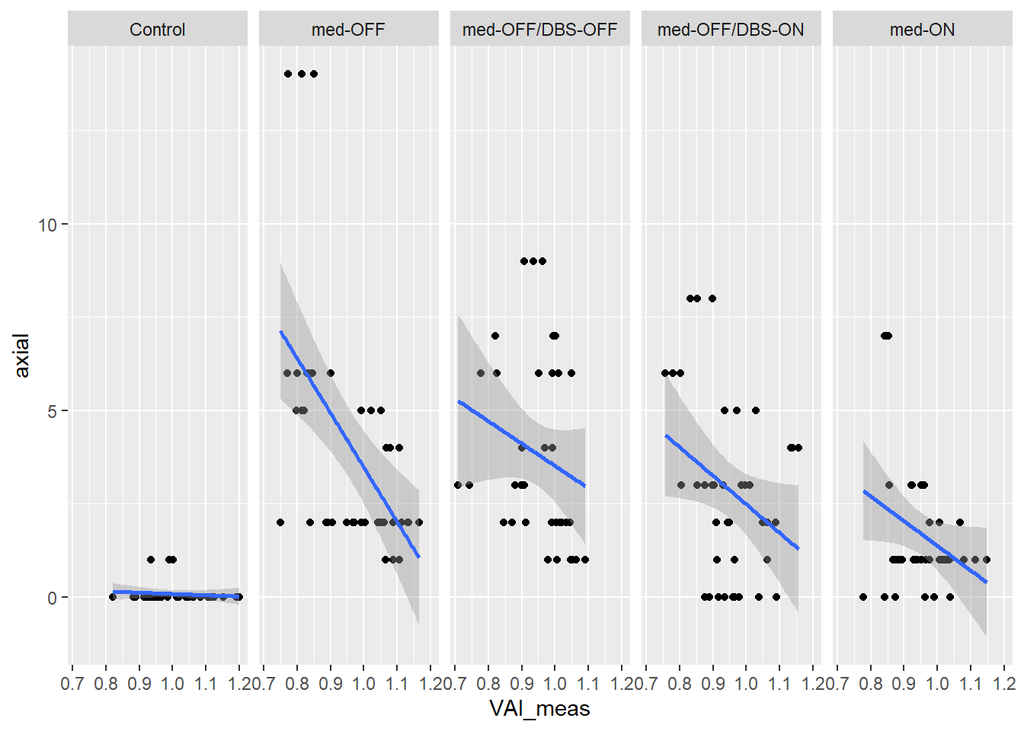

```r
ggplot(data_new, aes(x=VAI_meas, y=axial)) +
  geom_point()+
  geom_smooth(method=lm)+
  facet_grid(.~med_con)
```

Calculate correlation coefficient between VAI and axial subscores

```r
## med-OFF
shapiro.test(data_medOFF$VAI_meas) # p = 0.0165
```

```
##
##  Shapiro-Wilk normality test
##
## data:  data_medOFF$VAI_meas
## W = 0.92884, p-value = 0.0165
```

```r
shapiro.test(data_medOFF$axial) # p = 1.661e-07
```

```
##
##  Shapiro-Wilk normality test
##
## data:  data_medOFF$axial
## W = 0.70724, p-value = 1.661e-07
```

```r
cor.test(data_medOFF$VAI_meas, data_medOFF$axial, method = "spearman") ## r(37) = -0.59, p = 7.198e-05
```

```
##
##  Spearman's rank correlation rho
##
## data:  data_medOFF$VAI_meas and data_medOFF$axial
## S = 15729, p-value = 7.198e-05
## alternative hypothesis: true rho is not equal to 0
## sample estimates:
##        rho
## -0.5919873
```

```r
## med-ON
shapiro.test(data_medON$VAI_meas) # p = 0.8574
```

```
##
##  Shapiro-Wilk normality test
##
## data:  data_medON$VAI_meas
## W = 0.98449, p-value = 0.8574
```

```r
shapiro.test(data_medON$axial) # p = 9.958e-08
```

```
##
##  Shapiro-Wilk normality test
##
## data:  data_medON$axial
## W = 0.69356, p-value = 9.958e-08
```

```r
cor.test(data_medON$VAI_meas, data_medON$axial, method = "spearman") ## r(37) = -0.15, n.s.
```

```
##
##  Spearman's rank correlation rho
##
## data:  data_medON$VAI_meas and data_medON$axial
## S = 11392, p-value = 0.3522
## alternative hypothesis: true rho is not equal to 0
## sample estimates:
##        rho
## -0.1530739
```

```r
## DBS-ON
shapiro.test(data_DBSON$VAI_meas) # p = 0.8184
```

```
##
##  Shapiro-Wilk normality test
##
## data:  data_DBSON$VAI_meas
## W = 0.98327, p-value = 0.8184
```

```r
shapiro.test(data_DBSON$axial) # p = 0.003841
```

```
##
##  Shapiro-Wilk normality test
##
## data:  data_DBSON$axial
## W = 0.90827, p-value = 0.003841
```

```r
cor.test(data_DBSON$VAI_meas, data_DBSON$axial, method = "spearman") ## r(37) = -0.29, n.s.
```

```
##
##  Spearman's rank correlation rho
##
## data:  data_DBSON$VAI_meas and data_DBSON$axial
## S = 12749, p-value = 0.07291
## alternative hypothesis: true rho is not equal to 0
## sample estimates:
##        rho
## -0.2904007
```

VAI ~ bradykinesia symptoms

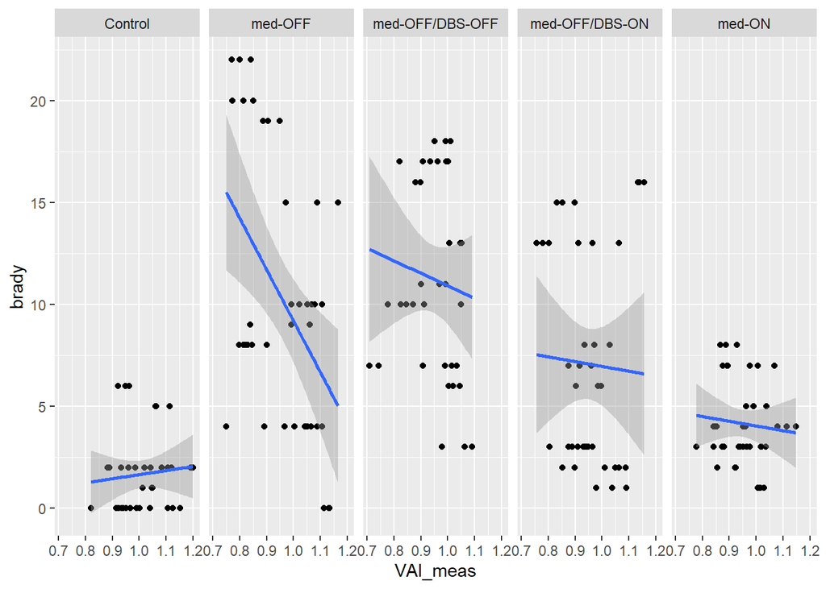

```r
ggplot(data_new, aes(x=VAI_meas, y=brady)) +
  geom_point()+
  geom_smooth(method=lm)+
  facet_grid(.~med_con)
```

Calculate correlation coefficient between VAI and brady subscores

```r
## med-OFF
shapiro.test(data_medOFF$VAI_meas) # p = 0.0165
```

```
##
##  Shapiro-Wilk normality test
##
## data:  data_medOFF$VAI_meas
## W = 0.92884, p-value = 0.0165
```

```r
shapiro.test(data_medOFF$brady) # p = 0.00371
```

```
##
##  Shapiro-Wilk normality test
##
## data:  data_medOFF$brady
## W = 0.90776, p-value = 0.00371
```

```r
cor.test(data_medOFF$VAI_meas, data_medOFF$brady, method = "spearman") ## r(37) = -0.39, p = 0.01534
```

```
##
##  Spearman's rank correlation rho
##
## data:  data_medOFF$VAI_meas and data_medOFF$brady
## S = 13689, p-value = 0.01534
## alternative hypothesis: true rho is not equal to 0
## sample estimates:
##        rho
## -0.3855751
```

```r
## med-ON
shapiro.test(data_medON$VAI_meas) # p = 0.8574
```

```
##
##  Shapiro-Wilk normality test
##
## data:  data_medON$VAI_meas
## W = 0.98449, p-value = 0.8574
```

```r
shapiro.test(data_medON$brady) # p =  0.001562
```

```
##
##  Shapiro-Wilk normality test
##
## data:  data_medON$brady
## W = 0.89471, p-value = 0.001562
```

```r
cor.test(data_medON$VAI_meas, data_medON$brady, method = "spearman") ## r(37) = -0.04, n.s.
```

```
##
##  Spearman's rank correlation rho
##
## data:  data_medON$VAI_meas and data_medON$brady
## S = 10289, p-value = 0.8026
## alternative hypothesis: true rho is not equal to 0
## sample estimates:
##         rho
## -0.04135232
```

```r
## DBS-ON
shapiro.test(data_DBSON$VAI_meas) # p = 0.8184
```

```
##
##  Shapiro-Wilk normality test
##
## data:  data_DBSON$VAI_meas
## W = 0.98327, p-value = 0.8184
```

```r
shapiro.test(data_DBSON$brady) # p = 0.0001026
```

```
##
##  Shapiro-Wilk normality test
##
## data:  data_DBSON$brady
## W = 0.84904, p-value = 0.0001026
```

```r
cor.test(data_DBSON$VAI_meas, data_DBSON$brady, method = "spearman") ## r(37) = -0.15, n.s.
```

```
##
##  Spearman's rank correlation rho
##
## data:  data_DBSON$VAI_meas and data_DBSON$brady
## S = 11372, p-value = 0.3587
## alternative hypothesis: true rho is not equal to 0
## sample estimates:
##        rho
## -0.1510374
```

VAI ~ symptoms of Posture and Gait

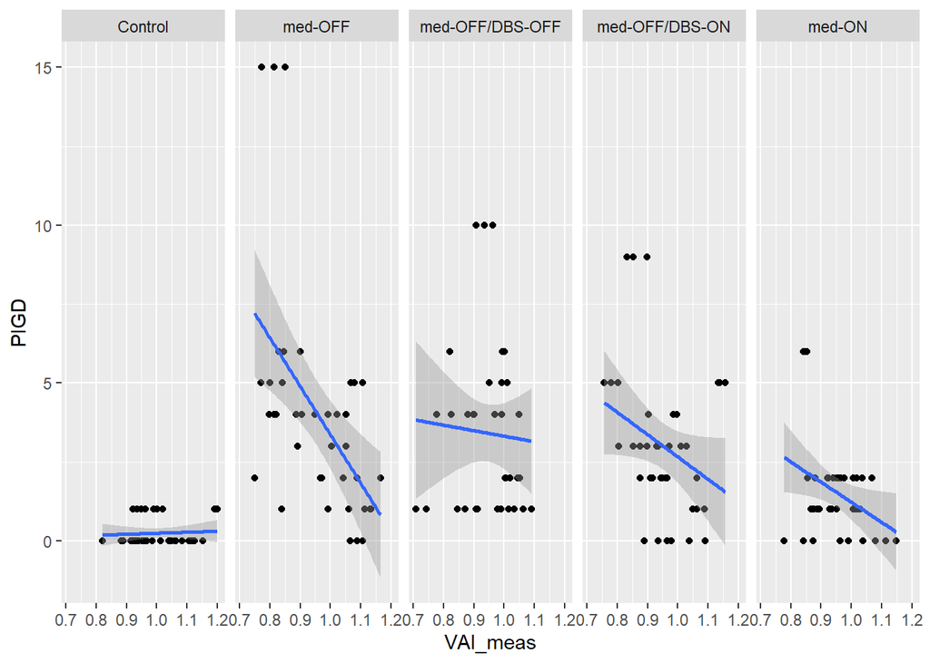

```r
ggplot(data_new, aes(x=VAI_meas, y=PIGD)) +
  geom_point()+
  geom_smooth(method=lm)+
  facet_grid(.~med_con)
```

Calculate correlation coefficient between VAI and PIGD

```r
## med-OFF
shapiro.test(data_medOFF$VAI_meas) # p = 0.0165
```

```
##
##  Shapiro-Wilk normality test
##
## data:  data_medOFF$VAI_meas
## W = 0.92884, p-value = 0.0165
```

```r
shapiro.test(data_medOFF$PIGD) # p =  8.088e-07
```

```
##
##  Shapiro-Wilk normality test
##
## data:  data_medOFF$PIGD
## W = 0.74716, p-value = 8.088e-07
```

```r
cor.test(data_medOFF$VAI_meas, data_medOFF$PIGD, method = "spearman") ## r(37) = -0.55, p = 0.0002896
```

```
##
##  Spearman's rank correlation rho
##
## data:  data_medOFF$VAI_meas and data_medOFF$PIGD
## S = 15311, p-value = 0.0002896
## alternative hypothesis: true rho is not equal to 0
## sample estimates:
##        rho
## -0.5496602
```

```r
## med-ON
shapiro.test(data_medON$VAI_meas) # p = 0.8574
```

```
##
##  Shapiro-Wilk normality test
##
## data:  data_medON$VAI_meas
## W = 0.98449, p-value = 0.8574
```

```r
shapiro.test(data_medON$PIGD) # p = 4.312e-07
```

```
##
##  Shapiro-Wilk normality test
##
## data:  data_medON$PIGD
## W = 0.73172, p-value = 4.312e-07
```

```r
cor.test(data_medON$VAI_meas, data_medON$PIGD, method = "spearman") ## r(37) = -0.21, n.s.
```

```
##
##  Spearman's rank correlation rho
##
## data:  data_medON$VAI_meas and data_medON$PIGD
## S = 11965, p-value = 0.1972
## alternative hypothesis: true rho is not equal to 0
## sample estimates:
##        rho
## -0.2110318
```

```r
## DBS-ON
shapiro.test(data_DBSON$VAI_meas) # p = 0.8184
```

```
##
##  Shapiro-Wilk normality test
##
## data:  data_DBSON$VAI_meas
## W = 0.98327, p-value = 0.8184
```

```r
shapiro.test(data_DBSON$PIGD) # p = 0.000613
```

```
##
##  Shapiro-Wilk normality test
##
## data:  data_DBSON$PIGD
## W = 0.87985, p-value = 0.000613
```

```r
cor.test(data_DBSON$VAI_meas, data_DBSON$PIGD, method = "spearman") ## r(37) = -0.33, p = 0.04325
```

```
##
##  Spearman's rank correlation rho
##
## data:  data_DBSON$VAI_meas and data_DBSON$PIGD
## S = 13095, p-value = 0.04325
## alternative hypothesis: true rho is not equal to 0
## sample estimates:
##        rho
## -0.3253868
```